Skip to main content

# Data summary of my five flux towers

Author

Rebecca Franke

Published

November 20, 2026

# Libraries

```r
# General stuff I need often
library(readr)
library(dplyr)
library(readr)
library(ggplot2)
library(tidyr)
library(stringr)
library(knitr)
```

# The function for the zip files

```r
# Create function
getwd()
```

```
[1] "C:/Users/Becky/Documents/3_Semester/Environmental Modelling/datascience_env_monit"
```

```r
read_hh <- function(zip_file) {

  keep <- c("TIMESTAMP_START", "TIMESTAMP_END", "TA_F", "SW_IN_F",
            "VPD_F", "P_F", "NETRAD", "G_F_MDS",
            "H_F_MDS", "H_F_MDS_QC", "LE_F_MDS",
            "LE_F_MDS_QC", "NEE_VUT_REF", "NEE_VUT_REF_QC",
            "GPP_NT_VUT_REF", "RECO_NT_VUT_REF")

  # Extract site ID from ZIP filename
  site <- tools::file_path_sans_ext(basename(zip_file))

  # Find the half-hourly file inside the ZIP
  hh_name <- grep("FLUXMET_HH",
                  unzip(zip_file, list = TRUE)$Name,
                  value = TRUE)

  # Extract the file into the unzipped folder
  unzip(zip_file, files = hh_name,
        exdir = "data/raw/unzipped")

  # Read the half-hourly data
  hh <- read_csv(
    file.path("data/raw/unzipped", hh_name),
    na = "-9999",
    col_select = any_of(keep),
    col_types = cols(
      TIMESTAMP_START = "c",
      TIMESTAMP_END = "c",
      .default = "d"
    )
  ) |>
    mutate(
      time = as.POSIXct(TIMESTAMP_START,
                        format = "%Y%m%d%H%M",
                        tz = "UTC"),
      site = site
    )

  return(hh)
}


# All files in one table
zip_files <- list.files(
  "data/raw",
  pattern = "\\.zip$",
  full.names = TRUE
)

# Apply function to every ZIP file
hh_data <- lapply(zip_files, read_hh) |>
  bind_rows()

# Do checks
# Number of observations
nrow(hh_data)
```

```
[1] 1595472
```

```r
# Check which sites were included
unique(hh_data$site)
```

```
[1] "AMF_US-GLE_FLUXNET_2005-2020_v1.3_r1"
[2] "ICOS_BE-Vie_FLUXNET_1996-2026_v1.3_r1"
[3] "ICOS_GF-Guy_FLUXNET_2004-2025_v1.3_r1"
[4] "JPF_JP-Mse_FLUXNET_2002-2009_v1.3_r1"
[5] "TERN_AU-Ync_FLUXNET_2012-2025_v1.3_r1"
```

```r
# Number of observations per site
hh_data |>
  count(site)
```

```
# A tibble: 5 × 2
  site                                       n
  <chr>                                  <int>
1 AMF_US-GLE_FLUXNET_2005-2020_v1.3_r1  280512
2 ICOS_BE-Vie_FLUXNET_1996-2026_v1.3_r1 543504
3 ICOS_GF-Guy_FLUXNET_2004-2025_v1.3_r1 385728
4 JPF_JP-Mse_FLUXNET_2002-2009_v1.3_r1  140256
5 TERN_AU-Ync_FLUXNET_2012-2025_v1.3_r1 245472
```

```r
# Check time range
range(hh_data$time)
```

```
[1] "1996-01-01 00:00:00 UTC" "2026-12-31 23:30:00 UTC"
```

```r
# Share of measured NEE
mean(hh_data$NEE_VUT_REF_QC == 0, na.rm = TRUE)
```

```
[1] 0.4097165
```

```r
### make conversion of time format permanent & get the site ids
hh_data <- hh_data |>
  mutate(
    time = as.POSIXct(time, tz = "UTC"),
    year = as.integer(format(time, "%Y")),
    date = as.Date(time),
    site_id = str_split(site, "_", simplify = TRUE)[, 2]
  )
```

# C1: Site overview

A table with one row per tower: site ID, name, country, IGBP class, latitude, longitude, first and last year, hub, and the data citation. Most of it is in your snapshot CSV. Add a simple map of the five sites (a world map with five points is enough).

## The table

```r
# Load data
snapshot <- read.csv("data/snapshots/fluxnet_shuttle_snapshot_20261113T105747.csv")
names(snapshot)
```

```
 [1] "data_hub"               "site_id"                "site_name"
 [4] "location_lat"           "location_long"          "igbp"
 [7] "network"                "team_member_name"       "team_member_role"
[10] "team_member_email"      "first_year"             "last_year"
[13] "download_link"          "fluxnet_product_name"   "product_citation"
[16] "product_id"             "oneflux_code_version"   "product_source_network"
```

```r
# Create table
five_towers <- c("US-GLE", "BE-Vie", "GF-Guy", "JP-Mse", "AU-Ync")
site_metadata <- snapshot |>
    filter(site_id %in% five_towers) |>
    distinct(site_id, .keep_all = TRUE) |>
    select(
    site_id   = site_id,
    name      = site_name,
    igbp      = igbp,
    latitude  = location_lat,
    longitude = location_long,
    hub       = data_hub,
    citation  = product_citation
  )

## Add countries
site_metadata <- site_metadata |>
  mutate(country = recode(substr(site_id, 1, 2),
                          "US" = "United States", "BE" = "Belgium",
                          "GF" = "French Guyana", "JP" = "Japan",
                          "AU" = "Australia")) |>
  relocate(country, .after = name)

## Add first & last year

site_years <- hh_data |>
  group_by(site) |>
  summarise(
    first_year = min(year, na.rm = TRUE),
    last_year  = max(year, na.rm = TRUE),
    .groups = "drop"
  )

# Now join, but problem with site IDs in site years
library(stringr)   # for str_split()
site_years <- site_years |>
  mutate(
    site_id = str_split(site, "_", simplify = TRUE)[, 2]   # extract the 2nd token
  ) |>
  # keep only the columns needed for the join
  select(site_id, first_year, last_year)

site_metadata <- site_metadata |>
  left_join(site_years, by = c("site_id" = "site_id")) |>
  # (optional) reorder columns for readability
  select(
    site_id, name, igbp,
    latitude, longitude,
    first_year, last_year,
    hub, citation
  )

site_metadata
```

```
  site_id                  name igbp  latitude   longitude first_year last_year
1  US-GLE                 GLEES  ENF  41.36650 -106.239900       2005      2020
2  JP-Mse Mase rice paddy field  CRO  36.05393  140.026930       2002      2009
3  GF-Guy              Guyaflux  EBF   5.27870  -52.924800       2004      2025
4  BE-Vie              Vielsalm   MF  50.30496    5.998099       1996      2026
5  AU-Ync                 Yanco  GRA -34.98780  146.290800       2012      2025
        hub
1 AmeriFlux
2      ICOS
3      ICOS
4      ICOS
5      TERN
                                                                                                                                                                                                                                                                                                            …
1                                                                                                                                                                  John Frank, George Valentine, Bill Massman (2026), AmeriFlux FLUXNET-1F US-GLE GLEES, Ver. v1.3_r1 (2005-2020), AmeriFlux AMP, (Dataset).…
2                                                                                                                                                                                        Iwata, H., Ono, K. (2026). Fluxnet Archive Product from Mase rice paddy field, 2002–2009, FLUXNET, https://hdl.hand…
3                                                                                                                                                                                     Bonal, D., Brechet, L., Burban, B. (2026). Fluxnet Archive Product from Guyaflux, 2004–2025, FLUXNET, https://hdl.hand…
4 Vincke, C., Bogaerts, G., Chebbi, W., Chopin, H., Clément, T., De Ligne, A., Demoulin, L., Douxfils, B., Engelmann, T., Faurès, A., Heinesch, B., Hoang, K., Manise, T., Orgun, A., Piret, A., Thyrion, T. (2026). Fluxnet Archive Product from Vielsalm, 1996-01-01–2026-09-06, FLUXNET, https://hdl.hand…
5                                                                                                                                                                                                     Beringer, J., Walker, J. (2026): Yanco FLUXNET Release 2026_r1 . Version 2026_r1. Terrestrial Ecosyste…
```

## The map

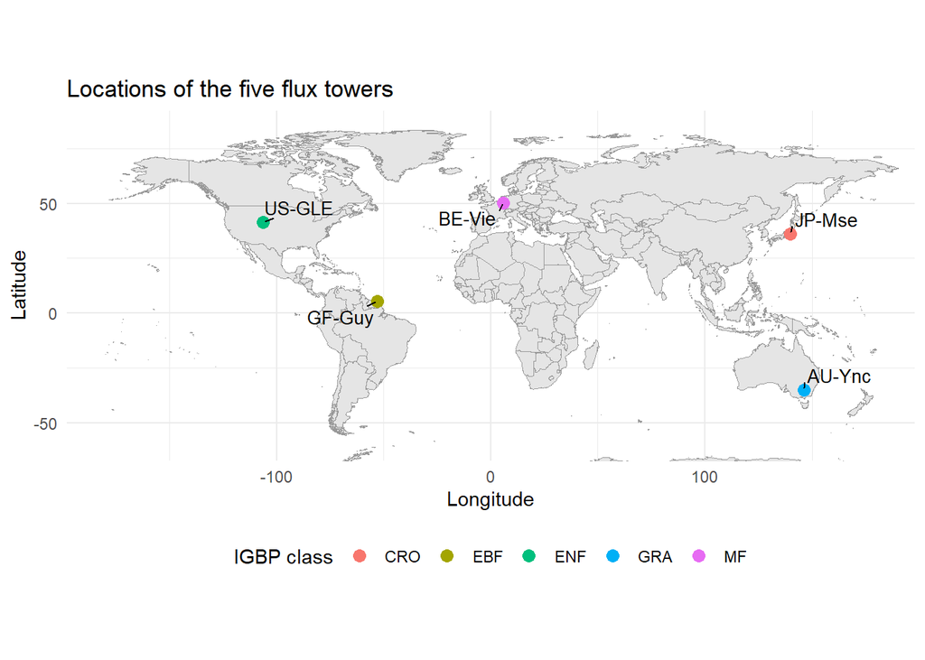

```r
# install.packages(c("maps", "ggrepel"))
library(maps)
library(ggrepel) # no overlaps

world <- map_data("world")

site_map <- ggplot() +
  geom_polygon(
    data = world,
    aes(x = long, y = lat, group = group),
    fill = "grey90", colour = "grey60", linewidth = 0.2
  ) +
  geom_point(
    data = site_metadata,
    aes(x = longitude, y = latitude, colour = igbp),
    size = 3
  ) +
  geom_text_repel(
    data = site_metadata,
    aes(x = longitude, y = latitude, label = site_id),
    size = 3.5, min.segment.length = 0
  ) +
  coord_quickmap(xlim = c(-180, 180), ylim = c(-60, 85)) +
  labs(
    title  = "Locations of the five flux towers",
    x = "Longitude", y = "Latitude", colour = "IGBP class"
  ) +
  theme_minimal() +
  theme(legend.position = "bottom")

site_map
```

# C2: Data coverage

For each site and year, the share of half hours in which NEE was measured (NEE_VUT_REF_QC == 0). Show it as a heat map: sites on the y-axis, years on the x-axis, colour = share measured. Add one sentence: which site and years have the best data?

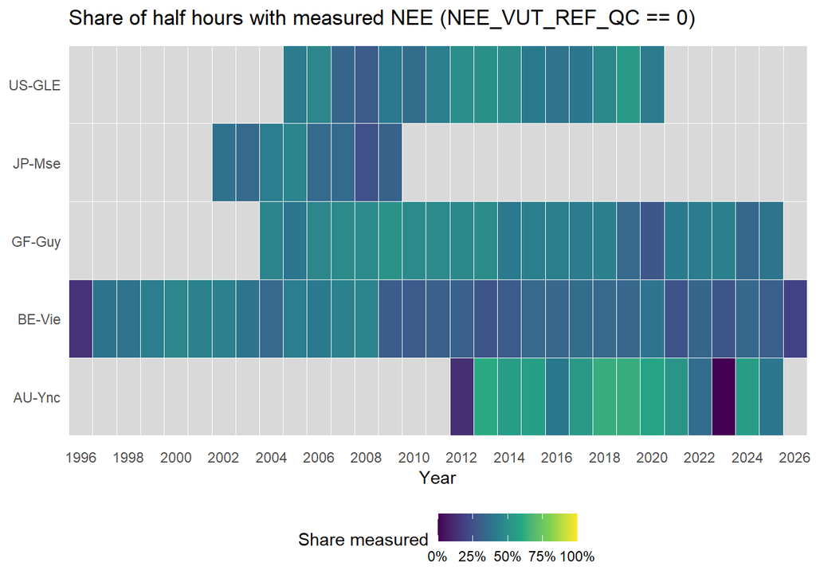

```r
nee_share <- hh_data |>
  group_by(site_id, year) |>
  summarise(
    n_total = n(),
    n_measured = sum(NEE_VUT_REF_QC == 0, na.rm = TRUE),  # NA QC counts as not measured
    share = n_measured / n_total,
    .groups = "drop"
  ) |>
  # make years without any rows show up as empty tiles instead of vanishing
  complete(site_id, year = full_seq(year, 1))



heatmap_nee <- ggplot(nee_share, aes(x = year, y = site_id, fill = share)) +
  geom_tile(colour = "white") +
  scale_fill_viridis_c(
    name = "Share measured",
    limits = c(0, 1),
    labels = scales::percent,
    na.value = "grey85"
  ) +
  scale_x_continuous(breaks = scales::breaks_width(2), expand = c(0, 0)) +
  labs(
    title = "Share of half hours with measured NEE (NEE_VUT_REF_QC == 0)",
    x = "Year", y = NULL
  ) +
  theme_minimal() +
  theme(panel.grid = element_blank(), legend.position = "bottom")

heatmap_nee
```

# C3: Summary statistics

A table per site with mean, minimum, maximum and % missing for TA_F, SW_IN_F, VPD_F, P_F, NEE_VUT_REF, GPP_NT_VUT_REF, RECO_NT_VUT_REF, H_F_MDS and LE_F_MDS. Give the units in the column headers. For precipitation, give the mean annual sum instead of the mean.

```r
vars <- c("TA_F", "SW_IN_F", "VPD_F", "P_F", "NEE_VUT_REF",
          "GPP_NT_VUT_REF", "RECO_NT_VUT_REF", "H_F_MDS", "LE_F_MDS")

# Column headers with units
labels <- c(
  TA_F            = "TA_F (°C)",
  SW_IN_F         = "SW_IN_F (W m⁻²)",
  VPD_F           = "VPD_F (hPa)",
  P_F             = "P_F (mm; mean = annual sum)",
  NEE_VUT_REF     = "NEE_VUT_REF (µmol CO₂ m⁻² s⁻¹)",
  GPP_NT_VUT_REF  = "GPP_NT_VUT_REF (µmol CO₂ m⁻² s⁻¹)",
  RECO_NT_VUT_REF = "RECO_NT_VUT_REF (µmol CO₂ m⁻² s⁻¹)",
  H_F_MDS         = "H_F_MDS (W m⁻²)",
  LE_F_MDS        = "LE_F_MDS (W m⁻²)"
)

dat <- hh_data |>
  # FLUXNET codes missing values as -9999; skip this line if already NA
  mutate(across(all_of(vars), ~ na_if(.x, -9999))) # replaces -9999 with nas

# Mean, min, max, % missing for every variable
stats_long <- dat |> # from wide to long format, stacking into two columns (variable and values) because I need the variables in rows
  pivot_longer(all_of(vars), names_to = "variable", values_to = "value") |>
  group_by(site_id, variable) |> # treat each site with var as group, so in summarrise there is a value for each variable per site
  summarise(
    Mean = mean(value, na.rm = TRUE), # ignoring NAs
    Min  = min(value, na.rm = TRUE),
    Max  = max(value, na.rm = TRUE),
    `% missing` = 100 * mean(is.na(value)), # percentage of missing values
    .groups = "drop" # stop the grouping from before to have next steps behave normally
  )

# Precipitation: replace the mean by the mean annual sum
precip_annual <- dat |>
  group_by(site_id, year) |> # new grouping to get sum mean per year
  summarise(annual_sum = sum(P_F, na.rm = TRUE), .groups = "drop") |> # now summarise per year and stop the groups
  group_by(site_id) |> # now means from sums before per site
  summarise(annual_mean = mean(annual_sum), .groups = "drop")

stats_long <- stats_long |> # now add the precipitation to the table
  left_join(precip_annual, by = "site_id") |> #
  mutate(Mean = if_else(variable == "P_F", annual_mean, Mean)) |>
  select(-annual_mean)

# Reshape: statistics as rows, variables (with units) as columns
site_table <- function(id) {
  stats_long |>
    filter(site_id == id) |> # get specific site
    mutate(variable = factor(variable, levels = vars, labels = labels[vars])) |> # swaps variable names for the previously named units
    pivot_longer(c(Mean, Min, Max, `% missing`), # 4 statistics columns are now rows
                 names_to = "Statistic", values_to = "value") |>
    pivot_wider(names_from = variable, values_from = value) |> # now the variables are back to columns
    mutate(Statistic = factor(Statistic, levels = c("Mean", "Min", "Max", "% missing"))) |> # making them factors in a specific order
    arrange(Statistic)  # now apply this order
}

tab_US_GLE <- site_table("US-GLE")
tab_BE_Vie <- site_table("BE-Vie")
tab_GF_Guy <- site_table("GF-Guy")
tab_JP_Mse <- site_table("JP-Mse")
tab_AU_Ync <- site_table("AU-Ync")

# Showing off the tables
library(knitr)
kable(tab_US_GLE, digits = 2, caption = "US-GLE")
```

US-GLE

| site_id | Statistic | GPP_NT_VUT_REF (µmol CO₂ m⁻² s⁻¹) | H_F_MDS (W m⁻²) | LE_F_MDS (W m⁻²) | NEE_VUT_REF (µmol CO₂ m⁻² s⁻¹) | P_F (mm; mean = annual sum) | RECO_NT_VUT_REF (µmol CO₂ m⁻² s⁻¹) | SW_IN_F (W m⁻²) | TA_F (°C) | VPD_F (hPa) |
| --- | --- | --- | --- | --- | --- | --- | --- | --- | --- | --- |
| US-GLE | Mean | 1.87 | 37.87 | 44.75 | -0.05 | 1350.8 | 1.85 | 185.50 | 0.26 | 3.90 |
| US-GLE | Min | -40.46 | -696.01 | -325.28 | -36.86 | 0.0 | 0.00 | 0.00 | -34.35 | 0.04 |
| US-GLE | Max | 38.49 | 1318.68 | 571.88 | 44.01 | 18.8 | 9.79 | 1214.21 | 23.21 | 24.04 |
| US-GLE | % missing | 2.50 | 1.28 | 1.28 | 2.50 | 0.0 | 2.50 | 0.00 | 0.00 | 0.00 |

```r
kable(tab_BE_Vie, digits = 2, caption = "BE-Vie")
```

BE-Vie

| site_id | Statistic | GPP_NT_VUT_REF (µmol CO₂ m⁻² s⁻¹) | H_F_MDS (W m⁻²) | LE_F_MDS (W m⁻²) | NEE_VUT_REF (µmol CO₂ m⁻² s⁻¹) | P_F (mm; mean = annual sum) | RECO_NT_VUT_REF (µmol CO₂ m⁻² s⁻¹) | SW_IN_F (W m⁻²) | TA_F (°C) | VPD_F (hPa) |
| --- | --- | --- | --- | --- | --- | --- | --- | --- | --- | --- |
| BE-Vie | Mean | 4.93 | 21.04 | 29.27 | -1.26 | 921.91 | 3.69 | 120.61 | 8.66 | 3.05 |
| BE-Vie | Min | -39.29 | -297.78 | -198.82 | -46.38 | 0.00 | 0.00 | 0.00 | -15.82 | 0.00 |
| BE-Vie | Max | 52.67 | 727.81 | 704.26 | 41.18 | 24.78 | 20.02 | 1108.27 | 35.29 | 51.20 |
| BE-Vie | % missing | 3.43 | 3.02 | 3.42 | 3.43 | 1.16 | 3.43 | 1.16 | 1.16 | 1.16 |

```r
kable(tab_GF_Guy, digits = 2, caption = "GF-Guy")
```

GF-Guy

| site_id | Statistic | GPP_NT_VUT_REF (µmol CO₂ m⁻² s⁻¹) | H_F_MDS (W m⁻²) | LE_F_MDS (W m⁻²) | NEE_VUT_REF (µmol CO₂ m⁻² s⁻¹) | P_F (mm; mean = annual sum) | RECO_NT_VUT_REF (µmol CO₂ m⁻² s⁻¹) | SW_IN_F (W m⁻²) | TA_F (°C) | VPD_F (hPa) |
| --- | --- | --- | --- | --- | --- | --- | --- | --- | --- | --- |
| GF-Guy | Mean | NaN | 19.57 | 98.23 | -0.56 | 3170.71 | NaN | 199.1 | 25.83 | 4.78 |
| GF-Guy | Min | Inf | -139.40 | -99.81 | -79.72 | 0.00 | Inf | 0.0 | 19.66 | 0.00 |
| GF-Guy | Max | -Inf | 461.40 | 991.12 | 49.87 | 45.00 | -Inf | 1259.0 | 33.49 | 26.07 |
| GF-Guy | % missing | 100 | 0.00 | 0.00 | 0.00 | 0.00 | 100 | 0.0 | 0.00 | 0.00 |

```r
kable(tab_JP_Mse, digits = 2, caption = "JP-Mse")
```

JP-Mse

| site_id | Statistic | GPP_NT_VUT_REF (µmol CO₂ m⁻² s⁻¹) | H_F_MDS (W m⁻²) | LE_F_MDS (W m⁻²) | NEE_VUT_REF (µmol CO₂ m⁻² s⁻¹) | P_F (mm; mean = annual sum) | RECO_NT_VUT_REF (µmol CO₂ m⁻² s⁻¹) | SW_IN_F (W m⁻²) | TA_F (°C) | VPD_F (hPa) |
| --- | --- | --- | --- | --- | --- | --- | --- | --- | --- | --- |
| JP-Mse | Mean | 2.53 | 6.10 | 64.86 | -0.53 | 5331.23 | 2.00 | 153.93 | 13.81 | 4.39 |
| JP-Mse | Min | -33.07 | -246.00 | -292.00 | -47.11 | 0.00 | 0.00 | 0.00 | -8.83 | 0.00 |
| JP-Mse | Max | 51.67 | 490.35 | 664.29 | 33.92 | 41.62 | 9.64 | 1055.00 | 36.50 | 34.80 |
| JP-Mse | % missing | 0.00 | 0.00 | 0.00 | 0.00 | 0.00 | 0.00 | 0.00 | 0.00 | 0.00 |

```r
kable(tab_AU_Ync, digits = 2, caption = "AU-Ync")
```

AU-Ync

| site_id | Statistic | GPP_NT_VUT_REF (µmol CO₂ m⁻² s⁻¹) | H_F_MDS (W m⁻²) | LE_F_MDS (W m⁻²) | NEE_VUT_REF (µmol CO₂ m⁻² s⁻¹) | P_F (mm; mean = annual sum) | RECO_NT_VUT_REF (µmol CO₂ m⁻² s⁻¹) | SW_IN_F (W m⁻²) | TA_F (°C) | VPD_F (hPa) |
| --- | --- | --- | --- | --- | --- | --- | --- | --- | --- | --- |
| AU-Ync | Mean | 1.35 | 51.69 | 30.39 | -0.38 | 525.07 | 0.96 | 216.01 | 17.13 | 9.05 |
| AU-Ync | Min | -47.10 | -100.00 | -97.00 | -79.90 | 0.00 | 0.00 | 0.00 | -4.24 | 0.00 |
| AU-Ync | Max | 79.90 | 591.00 | 499.00 | 47.72 | 35.00 | 10.75 | 1320.00 | 45.87 | 82.32 |
| AU-Ync | % missing | 15.74 | 8.60 | 14.34 | 15.74 | 0.00 | 15.74 | 0.00 | 0.00 | 0.00 |

## Checking Guyana because it has no GPP or RECO values

This code did not work when rendering, it just checked whether there was an error from me or if there really is no GPP and Reco data for Guyana in the data with the variables that were pre-selected for us in the first zipping code.

```r
#tab <- hh_data |>group_by(site_id) |>summarise(across(c(NEE_VUT_REF, GPP_NT_VUT_REF, RECO_NT_VUT_REF),list(n_valid = ~ sum(!is.na(.x) & .x != -9999),n_fill  = ~ sum(.x == -9999, na.rm = TRUE))))

#hh_data |> filter(site_id == "GF-Guy") |>summarise(across(c(GPP_DT_VUT_REF, RECO_DT_VUT_REF),~ sum(!is.na(.x) & .x != -9999)))

#grep("GPP|RECO", names(hh_data), value = TRUE)
```

Guyana has no GPP or RECO values (100% missing) and no daytime partitioning (DT) is available in the data, so only NEE is shown for this site.

# C4: Time series

Aggregate the half-hourly data to daily values yourself and plot daily NEE, GPP and RECO over the whole record, one panel per site.

Unit conversion: 1 µmol CO₂ m⁻² s⁻¹ = 1.0378 g C m⁻² d⁻¹ (× 86 400 s × 12.011 g mol⁻¹ × 10⁻⁶). So a daily mean in µmol m⁻² s⁻¹ × 1.0378 gives g C m⁻² d⁻¹.

Check your aggregation once against the daily FLUXMET_DD file for one site.

```r
# Daily fluxes
conv <- 1.0378 # 1 µmol CO₂ m⁻² s⁻¹ = 1.0378 g C m⁻² d⁻¹
flux_vars <- c("NEE_VUT_REF", "GPP_NT_VUT_REF", "RECO_NT_VUT_REF")

daily <- hh_data |>
  mutate(across(all_of(flux_vars), ~ na_if(.x, -9999))) |>
  group_by(site_id, date) |>
  summarise(n_hh = n(),
  across(all_of(flux_vars), ~ mean(.x, na.rm = TRUE) * conv),
  .groups = "drop"
  )

# Now plot one panel per site
daily_long <- daily |>
  pivot_longer(all_of(flux_vars), names_to = "variable", values_to = "value") |>
  mutate(variable = recode(variable, NEE_VUT_REF = "NEE",GPP_NT_VUT_REF  = "GPP", RECO_NT_VUT_REF = "RECO"))

daily_plot <- ggplot(daily_long, aes(x = date, y = value, colour = variable)) +
  geom_line(linewidth = 0.4, na.rm = TRUE) +
  facet_wrap(~ site_id, scales = "free_x", ncol = 1) +
  labs(
    title = "Daily fluxes of NEE, GPP and RECO",
    x = NULL, y = "Flux (g C m⁻² d⁻¹)"
  ) +
  theme_minimal()+
  theme(legend.position = "bottom")
```

## The plot

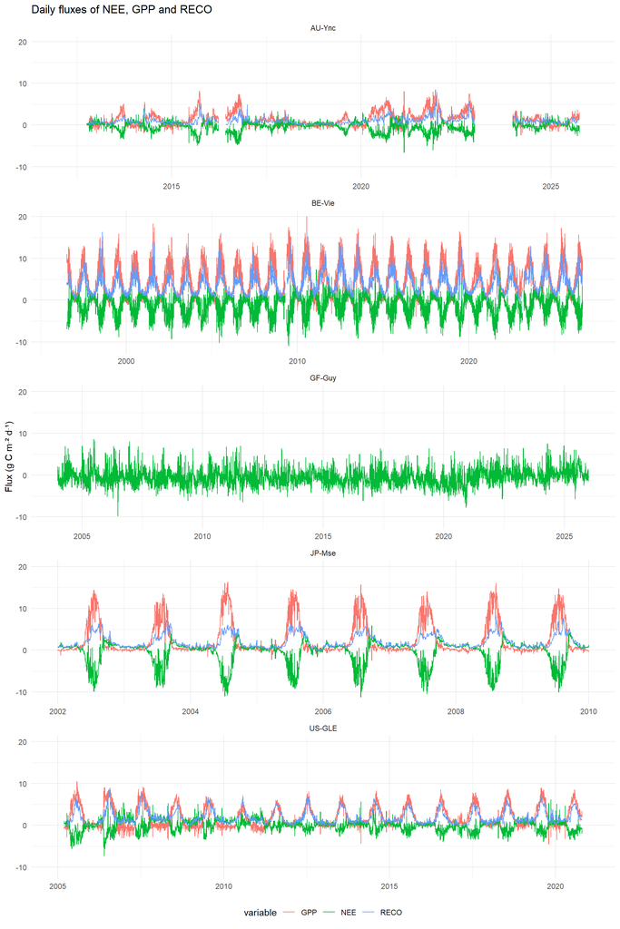

## Check up

### Unzip the file for US-GLE

```r
keep_2 <- c("TIMESTAMP", "TA_F", "SW_IN_F", "VPD_F", "P_F",
          "NETRAD", "G_F_MDS", "H_F_MDS", "H_F_MDS_QC", "LE_F_MDS", "LE_F_MDS_QC",
          "NEE_VUT_REF", "NEE_VUT_REF_QC", "GPP_NT_VUT_REF", "RECO_NT_VUT_REF")

zip_file <- list.files("data/raw", pattern = "\\.zip$", full.names = TRUE)[1]
dd_name  <- grep("FLUXMET_DD", unzip(zip_file, list = TRUE)$Name, value = TRUE)
unzip(zip_file, files = dd_name, exdir = "data/raw/unzipped")

dd <- read_csv(file.path("data/raw/unzipped", dd_name),
               na = "-9999",
               col_select = any_of(keep_2),
               col_types = cols(TIMESTAMP = "c", .default = "d")) |>
  mutate(time = as.POSIXct(TIMESTAMP, format = "%Y%m%d", tz = "UTC"))

nrow(dd)
```

```
[1] 5844
```

```r
range(dd$time)
```

```
[1] "2005-01-01 UTC" "2020-12-31 UTC"
```

```r
mean(dd$NEE_VUT_REF_QC == 0, na.rm = TRUE)   # share of measured NEE
```

```
[1] 0.02018606
```

### Do the comparison

```r
dd <- read.csv("data/raw/unzipped/AMF_US-GLE_FLUXNET_FLUXMET_DD_2005-2020_v1.3_r1.csv") |>
  mutate(date = as.Date(as.character(TIMESTAMP), format = "%Y%m%d")) |>
  select(date, NEE_dd = NEE_VUT_REF, GPP_dd = GPP_NT_VUT_REF, RECO_dd = RECO_NT_VUT_REF) |>
  mutate(across(c(NEE_dd, GPP_dd, RECO_dd), ~ na_if(.x, -9999)))

# get the daily data for US-GLE
check <- daily |>
  filter(site_id == "US-GLE") |>
  inner_join(dd, by = "date") |>
  mutate(
    d_NEE  = NEE_VUT_REF     - NEE_dd,
    d_GPP  = GPP_NT_VUT_REF  - GPP_dd,
    d_RECO = RECO_NT_VUT_REF - RECO_dd
  )

# do summaries and correlation
summary(check[, c("d_NEE", "d_GPP", "d_RECO")])
```

```
     d_NEE              d_GPP              d_RECO
 Min.   :-1.19309   Min.   :-5.15508   Min.   :0.00000
 1st Qu.:-0.04171   1st Qu.:-0.05946   1st Qu.:0.00005
 Median :-0.00027   Median :-0.00187   Median :0.00010
 Mean   :-0.02504   Mean   :-0.00244   Mean   :0.00014
 3rd Qu.: 0.00685   3rd Qu.: 0.04249   3rd Qu.:0.00020
 Max.   : 2.56200   Max.   : 3.12085   Max.   :0.00063
 NA's   :147        NA's   :147        NA's   :147
```

```r
cor(check$NEE_VUT_REF, check$NEE_dd, use = "complete.obs") # 0.9933843:
```

```
[1] 0.9933843
```

```r
cor(check$GPP_NT_VUT_REF, check$GPP_dd, use = "complete.obs") # 0.9921102
```

```
[1] 0.9921102
```

```r
cor(check$RECO_NT_VUT_REF, check$RECO_dd, use = "complete.obs") # 1
```

```
[1] 1
```

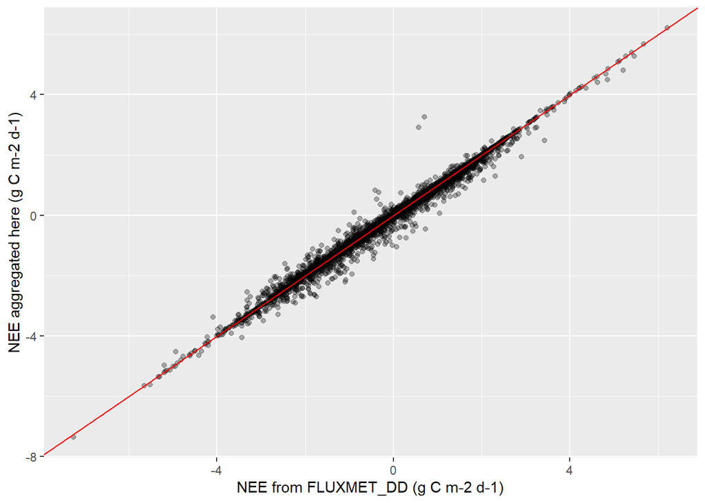

```r
#  Very good, but small differences probably due to different aggregation methods

# Plot NEE as example: looks good!
ggplot(check, aes(NEE_dd, NEE_VUT_REF)) +
  geom_point(alpha = 0.3) +
  geom_abline(colour = "red") +
  labs(x = "NEE from FLUXMET_DD (g C m-2 d-1)",
       y = "NEE aggregated here (g C m-2 d-1)")
```

# C5: Diurnal cycles

The mean daily course (hour of day on the x-axis) of NEE and LE for each season, all five sites in one figure. Careful: seasons are reversed in the southern hemisphere. Use latitude to define the seasons correctly and say how you did it.

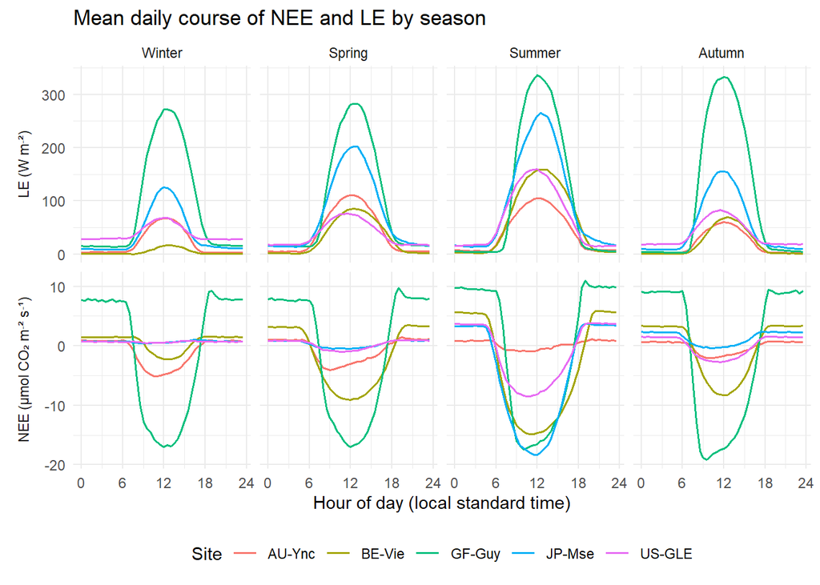

```r
# Latitude per site from the C1 table
site_lat <- site_metadata |> select(site_id, latitude)

diurnal <- hh_data |>
  left_join(site_lat, by = "site_id") |>
  mutate(
    across(c(NEE_VUT_REF, LE_F_MDS), ~ na_if(.x, -9999)),
    month = as.integer(format(time, "%m")), # new column month for season calculation
    hour = as.integer(format(time, "%H")) + as.integer(format(time, "%M")) / 60, # hour of the day as decimal number

    # Northern-hemisphere seasons by month (meteorological)
    season_n = case_when(
      month %in% c(12, 1, 2) ~ "Winter",
      month %in% c(3, 4, 5)  ~ "Spring",
      month %in% c(6, 7, 8)  ~ "Summer",
      month %in% c(9, 10, 11) ~ "Autumn"),
    # Southern hemisphere (latitude < 0): swapping
    season = if_else(latitude < 0,
      recode(season_n, Winter = "Summer", Summer = "Winter", Spring = "Autumn", Autumn = "Spring"), season_n),
    season = factor(season, levels = c("Winter", "Spring", "Summer", "Autumn"))
  ) |>
  group_by(site_id, season, hour) |>
  summarise(
    NEE = mean(NEE_VUT_REF, na.rm = TRUE),
    LE  = mean(LE_F_MDS, na.rm = TRUE),
    .groups = "drop"
  ) |>
  pivot_longer(c(NEE, LE), names_to = "variable", values_to = "value") |>
  mutate(variable = recode(variable, NEE = "NEE (µmol CO₂ m⁻² s⁻¹)", LE  = "LE (W m⁻²)"))

diurnal_plot <- ggplot(diurnal, aes(hour, value, colour = site_id)) +
  geom_line(linewidth = 0.7) +
  facet_grid(variable ~ season, scales = "free_y", switch = "y") +
  scale_x_continuous(breaks = seq(0, 24, 6)) +
  labs(title  = "Mean daily course of NEE and LE by season",
    x = "Hour of day (local standard time)", y = NULL, colour = "Site") +
  theme_minimal() +
  theme(legend.position = "bottom", strip.placement = "outside")

diurnal_plot
```

The seasons were defined as meterological seasons by calendar months (December-February = Winter, March-May = Spring, June-August = Summer, September-November = Autumn) for the northern hemisphere. For the southern hemisphere, the seasons were swapped (Winter to Summer, Spring to Autumn). This was based on the negative latitude in the southern hemisphere. The latitude for finding the hemisphere was taken from the snapshot table.

# C6: Your reading

1. Energy balance for one tower: scatter of H_F_MDS + LE_F_MDS against NETRAD − G_F_MDS, using only half hours where H and LE were measured (_QC == 0). Add the 1:1 line and the slope of a linear fit. Some towers have no NETRAD or G; pick one that has them.
2. 5–8 sentences comparing your towers: which takes up the most carbon per year, which has the largest seasonal cycle, which surprised you, and how much of the data is gap-filled.

## Energy balance for one tower

```r
# Find a fitting tower
needed <- c("NETRAD", "G_F_MDS", "H_F_MDS", "LE_F_MDS", "H_F_MDS_QC", "LE_F_MDS_QC")
needed %in% names(hh_data)   # all must be TRUE
```

```
[1] TRUE TRUE TRUE TRUE TRUE TRUE
```

```r
hh_data |>
  group_by(site_id) |>
  summarise(across(c(NETRAD, G_F_MDS),
                   ~ round(100 * mean(is.na(.x) | .x == -9999), 1),
                   .names = "{.col}_pct_missing"))
```

```
# A tibble: 5 × 3
  site_id NETRAD_pct_missing G_F_MDS_pct_missing
  <chr>                <dbl>               <dbl>
1 AU-Ync                11.8                 8
2 BE-Vie                11.2                61.4
3 GF-Guy                 2.8               100
4 JP-Mse                62.8                33.7
5 US-GLE                 3.6                 1
```

```r
# Result: US-Gle has least missing data for NETRAD and G_F_MDS

# Prep data & fit

site_sel <- "US-GLE" # using US-GLE

eb <- hh_data |>
  filter(site_id == site_sel,
         H_F_MDS_QC == 0, LE_F_MDS_QC == 0) |> # H and LE measured
  mutate(across(c(NETRAD, G_F_MDS, H_F_MDS, LE_F_MDS), ~ na_if(.x, -9999))) |>
  mutate(
    turb  = H_F_MDS + LE_F_MDS, # turbulent fluxes
    avail = NETRAD - G_F_MDS # available energy
  ) |>
  filter(!is.na(turb), !is.na(avail))

fit <- lm(turb ~ avail, data = eb)
coef(fit)
```

```
(Intercept)       avail
 23.1492206   0.7206918
```

```r
summary(fit)$r.squared
```

```
[1] 0.9036708
```

```r
nrow(eb)
```

```
[1] 200406
```

```r
slope <- coef(fit)[["avail"]]
slope # 0.7206918
```

```
[1] 0.7206918
```

```r
icept <- coef(fit)[["(Intercept)"]]
icept # 23.14922
```

```
[1] 23.14922
```

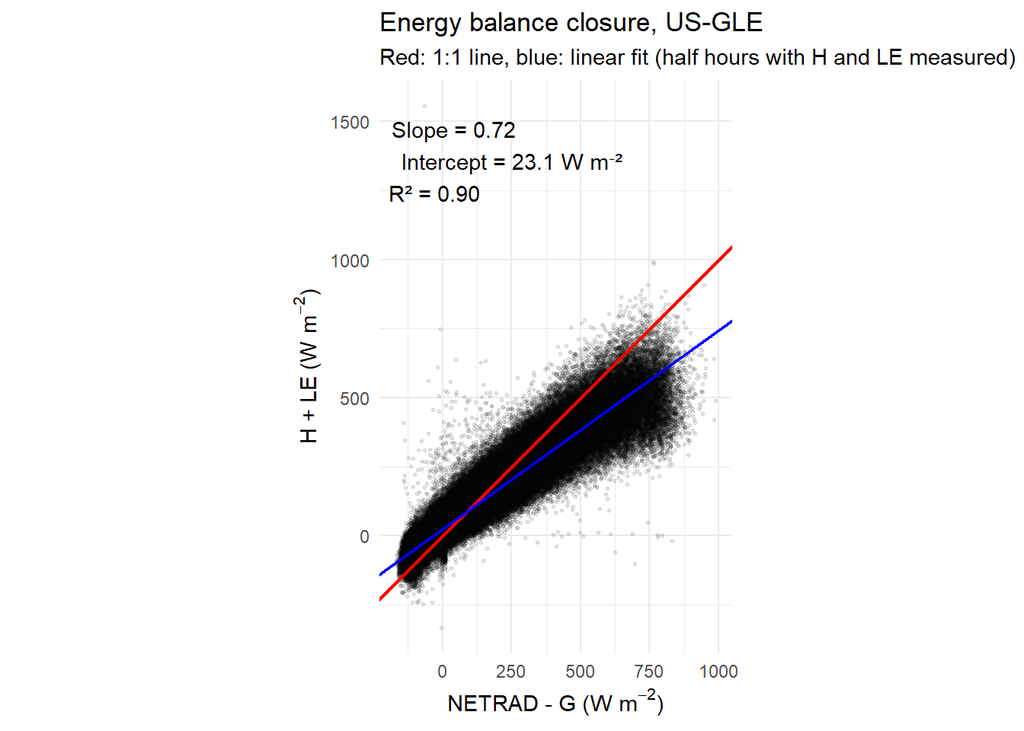

```r
eb_plot <- ggplot(eb, aes(avail, turb)) +
  geom_point(alpha = 0.1, size = 0.6) +
  geom_abline(intercept = 0, slope = 1, colour = "red", linewidth = 0.8) +
  geom_abline(intercept = icept, slope = slope, colour = "blue", linewidth = 0.8) +
  annotate("text", x = -Inf, y = Inf, hjust = -0.1, vjust = 1.5,
           label = sprintf("Slope = %.2f\nIntercept = %.1f W m\u207b\u00b2\nR\u00b2 = %.2f",
                           slope, icept, summary(fit)$r.squared)) +
  labs(title = paste("Energy balance closure,", site_sel),
       subtitle = "Red: 1:1 line, blue: linear fit (half hours with H and LE measured)",
       x = expression("NETRAD - G (W " * m^-2 * ")"),
       y = expression("H + LE (W " * m^-2 * ")")) +
  coord_equal() +
  theme_minimal()

eb_plot
```

Quick interpretation of the plot: The slope of the linear fit (in blue) is less than 1 (in red), indicating that the turbulent fluxes (H + LE) are generally lower than the available energy (NETRAD - G). The intercept of the fit is positive, suggesting that even when the available energy is low, there is still a baseline level of turbulent flux, which is typical for the night. The high R² value (0.90) indicates a strong linear relationship between the available energy and the turbulent fluxes, but the deviation from the 1:1 line suggests that not all available energy is being converted into turbulent fluxes.

## Comparison of the five towers

```r
# Mean annual uptake
annual_nee <- daily |>
  mutate(year = as.integer(format(date, "%Y"))) |>
  group_by(site_id, year) |>
  summarise(n_days = sum(!is.na(NEE_VUT_REF)),
            nee_sum = sum(NEE_VUT_REF, na.rm = TRUE),
            .groups = "drop") |>
  filter(n_days >= 360)

annual_nee |>
  group_by(site_id) |>
  summarise(mean_annual_NEE = mean(nee_sum), n_years = n()) |>
  arrange(mean_annual_NEE)
```

```
# A tibble: 5 × 3
  site_id mean_annual_NEE n_years
  <chr>             <dbl>   <int>
1 BE-Vie           -469.       27
2 GF-Guy           -211.       22
3 JP-Mse           -202.        8
4 AU-Ync           -138.       10
5 US-GLE             14.3      14
```

```r
# Vielsalm takes up most!

# Gapfilling in percentage
gap <- nee_share |>
  group_by(site_id) |>
  summarise(pct_measured   = 100 * sum(n_measured, na.rm = TRUE) / sum(n_total, na.rm = TRUE),
            pct_gapfilled  = 100 - pct_measured)

gap
```

```
# A tibble: 5 × 3
  site_id pct_measured pct_gapfilled
  <chr>          <dbl>         <dbl>
1 AU-Ync          46.1          53.9
2 BE-Vie          34.3          65.7
3 GF-Guy          42.6          57.4
4 JP-Mse          35.7          64.3
5 US-GLE          42.2          57.8
```

# Data and citation

## Site data

The data come from the FLUXNET data hub (snapshot `fluxnet_shuttle_snapshot_20261113T105747.csv`). The data citations for the five sites are:

- **US-GLE** (GLEES): John Frank, George Valentine, Bill Massman (2026), AmeriFlux FLUXNET-1F US-GLE GLEES, Ver. v1.3_r1 (2005-2020), AmeriFlux AMP, (Dataset). https://doi.org/10.17190/AMF/1871136
- **JP-Mse** (Mase rice paddy field): Iwata, H., Ono, K. (2026). Fluxnet Archive Product from Mase rice paddy field, 2002–2009, FLUXNET, https://hdl.handle.net/11676/496cflc8MbepzdjJvLU5v4cg
- **GF-Guy** (Guyaflux): Bonal, D., Brechet, L., Burban, B. (2026). Fluxnet Archive Product from Guyaflux, 2004–2025, FLUXNET, https://hdl.handle.net/11676/NWyicIqnZ9k5ECe3WLq8BvOK
- **BE-Vie** (Vielsalm): Vincke, C., Bogaerts, G., Chebbi, W., Chopin, H., Clément, T., De Ligne, A., Demoulin, L., Douxfils, B., Engelmann, T., Faurès, A., Heinesch, B., Hoang, K., Manise, T., Orgun, A., Piret, A., Thyrion, T. (2026). Fluxnet Archive Product from Vielsalm, 1996-01-01–2026-09-06, FLUXNET, https://hdl.handle.net/11676/PZh-nxtZjfrymcZJu9U4uLBJ
- **AU-Ync** (Yanco): Beringer, J., Walker, J. (2026): Yanco FLUXNET Release 2026_r1 . Version 2026_r1. Terrestrial Ecosystem Research Network (TERN). (Dataset).

## Acknowledgment

FLUXNET data products were produced and harmonized by eddy covariance regional networks and data processing centers, including AmeriFlux, ChinaFlux, European Fluxes Database, ICOS, JapanFlux, KoFlux, OzFlux, SAEON, and TERN. These products also include a modified version of ERA5 hourly data provided by the Copernicus Climate Change Service.